# Covid-19: Scoping the field

Orestis, Lio

17 May, 2020

# 1 Data description

I compiled the data set by collecting country-level variables from a host of sources.

- google mobility reports: displays the change in visits to places like grocery stores and parks as of 29/03/2020 (the report was released on the 2nd of April I think but it covers up to 3 days before).
  - The beginning of the observation period (compared to the benchmark) is Feb. 23. This seems to be consistent across all countries.
  - The baseline is the median value, for the corresponding day of the week, during the 5- week period Jan 3–Feb 6, 2020.
  - There is a new update on the 9th of April. They will keep on updating.
- official lock-down dates for each country (various sources).
- dates of first death and 1st reported case. I have also the dates for each additional death and case-confired.
- world bank measures for GDP per capita, unemployment and other health related indexes.
- Rule of Law from 2018 (this is a measure that was also included in the antisocial punishment paper by Gachter et al.)
- Number of tests and deaths - though this is sth that needs to be updated ever so often
- from World Value Scales: values such as the importance of democracy and respect for ind. human rights nowadays
- average temperature and humididty for the period between 22nd of January to March 24 (thanks to World Weather Online AP)
- demographics such as median age, population, population density, urban density
- behavioural variables such as the Rule of Law (from World Bank), risk taking propensity, altruism, patience, etc. (from the global preferences survey).

Some important dates to consider:

- 11/03/2020 : The World Health Organisation declares COVID-19 a pandemic.
- 21-22/01/2020: First official reports conceding there are human-to-human transmissions.
- 23/02/2020: Start of observation period for mobility restrictions.
- 29/03/2020: end of observation period for 1st Google report.
- 05/04/2020: end of observation period for 2nd Google report.
- 22/01/2020 - 24/03/2020: period of weather observation

The idea was to explore the ability of measures such as such the rule of law, importance of democracy and respect of individual rights to correlate with a) policy decisions such as when to apply restriction measures and how severe those are and b) with individual compliance: how much was mobility restricted.

Disclaimer: this is not an attempt to identify causal relations. This is just a report to satisfy curiocities that were raised over coffee-breaks. If we are to make a more serious scientific claims to motivate this, I guess we can claim the following two-fold contribution: 1. Assessing the usefulness of social-value indexes such as the ROL, etc. 2. Present a case for future studies, with more ambitious identification strategies, that aim to infer causality.

# 2 Movement analysis

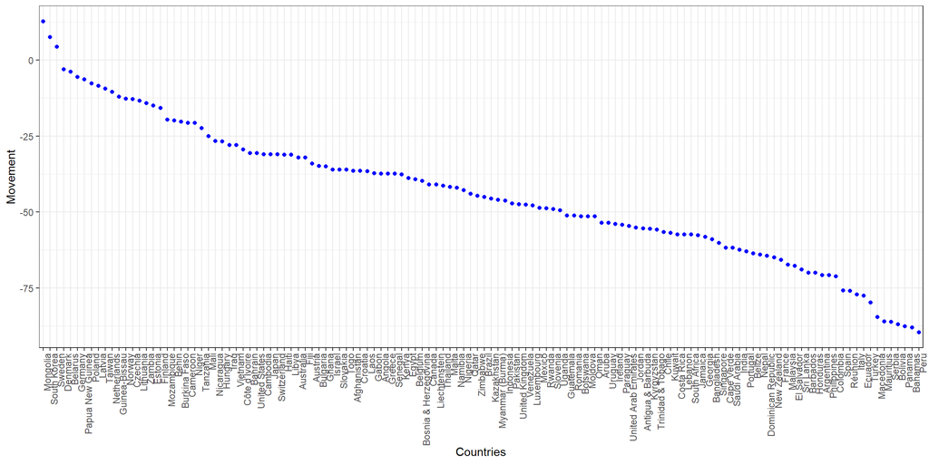

Figure 2.1: Movement restriction across countries

I focus on the dependent variable: “Movement” for the moment. This variable is based on Google reports. I aggregate a single score per country by taking the average on all categories (Parks, Groceries…) except “residential”. Residential measures: “Movement trends for places of residence”. Unlike the other categories, residential goes up during this period (people typically move around their houses more).

Movement probably captures two (latent for the moment) variables: a. governments’ stricness of enforcing the measures b. citizens’ obedience to governments’ mandate. Although the source is reliable, it’s prob. good to keep in mind that there are strong selection issues: the variable captures the behaviour of people who use smartphones and have allowed Google to track their location.

Table 2.1: Determinants of Movement: ‘Interesting’

|  | Movement |  |  |
| --- | --- | --- | --- |
| Predictors | Estimates | CI | p |
| (Intercept) | 96.58 | -23.16 – 216.31 | 0.111 |
| Lock [Yes] | -30.28 | -49.83 – -10.73 | **0.003** |
| log_GDP_pc | -5.36 | -16.19 – 5.47 | 0.324 |
| DaysDuration | 0.16 | -0.71 – 1.02 | 0.718 |
| Days_LockDown_1death | -0.02 | -0.51 – 0.48 | 0.947 |
| ROL | 9.33 | -2.20 – 20.87 | 0.110 |
| HumidityDif | 0.54 | -0.49 – 1.56 | 0.297 |
| Humidity | -0.47 | -0.93 – -0.01 | **0.046** |
| TemperatureDif | -0.93 | -4.22 – 2.35 | 0.570 |
| Temperature | -1.33 | -2.12 – -0.54 | **0.001** |
| Unemployment | -1.06 | -2.14 – 0.01 | 0.053 |
| Pop_Density_sq_mi | 0.01 | -0.03 – 0.04 | 0.684 |
| risktaking | 2.36 | -20.42 – 25.13 | 0.836 |
| patience | -6.13 | -31.56 – 19.29 | 0.630 |
| Observations | 62 |  |  |
| R<sup>2</sup> / R<sup>2</sup> adjusted | 0.467 / 0.322 |  |  |

Table 2.1: Determinants of Movement: ‘Best’

|  | Movement |  |  |
| --- | --- | --- | --- |
| Predictors | Estimates | CI | p |
| (Intercept) | 23.67 | -44.66 – 92.00 | 0.493 |
| Lock [Yes] | -28.60 | -40.38 – -16.83 | **<0.001** |
| log_GDP_pc | 0.15 | -6.28 – 6.59 | 0.962 |
| DaysDuration | 0.43 | -0.13 – 1.00 | 0.128 |
| Days_LockDown_1death | -0.03 | -0.33 – 0.27 | 0.843 |
| ROL | 6.16 | -0.17 – 12.49 | 0.056 |
| HumidityDif | 0.13 | -0.41 – 0.66 | 0.636 |
| Humidity | -0.40 | -0.68 – -0.12 | **0.005** |
| TemperatureDif | -0.87 | -3.06 – 1.32 | 0.431 |
| Temperature | -1.25 | -1.71 – -0.79 | **<0.001** |
| Unemployment | -0.94 | -1.68 – -0.20 | **0.014** |
| Death_disease | 0.52 | 0.19 – 0.84 | **0.002** |
| Pop_Density_sq_mi | -0.00 | -0.01 – 0.00 | 0.734 |
| Observations | 106 |  |  |
| R<sup>2</sup> / R<sup>2</sup> adjusted | 0.520 / 0.458 |  |  |

In principle, the really important explanatory variables, should persist (i.e. be significant) in both regressions. Unless of course, there is a pattern in the countries that drop out. In principle, this should not be the case as Briq claims to have a representative sample of the world in its measurements. Let’s see, which countries are included in Google’s reports but not in Briq:

```
##  [1] Angola             Antigua & Barbuda  Aruba              Bahamas
##  [5] Bahrain            Barbados           Belarus            Belgium
##  [9] Belize             Benin              Bulgaria           Burkina Faso
## [13] Cape Verde         Côte d’Ivoire      Côte d’Ivoire      Denmark
## [17] Dominican Republic Ecuador            El Salvador        Fiji
## [21] Gabon              Guinea-Bissau      Honduras           Ireland
## [25] Jamaica            Kuwait             Kyrgyzstan         Laos
## [29] Latvia             Lebanon            Libya              Liechtenstein
## [33] Luxembourg         Macedonia          Malaysia           Mali
## [37] Malta              Mauritius          Mongolia           Mozambique
## [41] Myanmar (Burma)    Namibia            Nepal              New Zealand
## [45] Niger              Norway             Oman               Panama
## [49] Papua New Guinea   Paraguay           Qatar              Réunion
## [53] Senegal            Singapore          Slovakia           Slovenia
## [57] Taiwan             Togo               Trinidad & Tobago  Uruguay
## [61] Zambia
## 199 Levels: Afghanistan Albania Algeria Andorra Angola ... Zimbabwe
```

Death_disease is a peculiar case for two reasons.[^1] First, the sign suggests that countries with higher %’s of communicable diseases (i.e. one that is spread from one person to another through a variety of ways that include: contact with blood and bodily fluids; breathing in an airborne virus; or by being bitten by an insect), tend to restrict their movement less during this pandemic. Second, including this variable crowds out the effect of GDP_pc. Perhaps this variable correlates too strongly with GDP_pc so the effect that is picking up is misleading. Figure 2.2 suggests that this is more likely the case.

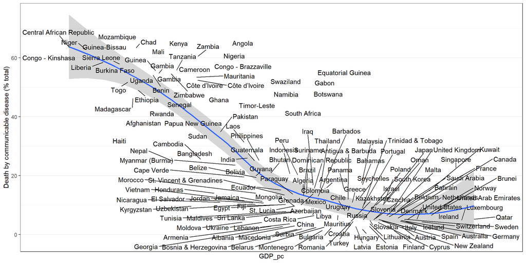

Goals:

- Find a proxy variable for how much a country likes to touch, hug and kiss each other.
- What crowds out ROL?

# 3 Death and total cases.

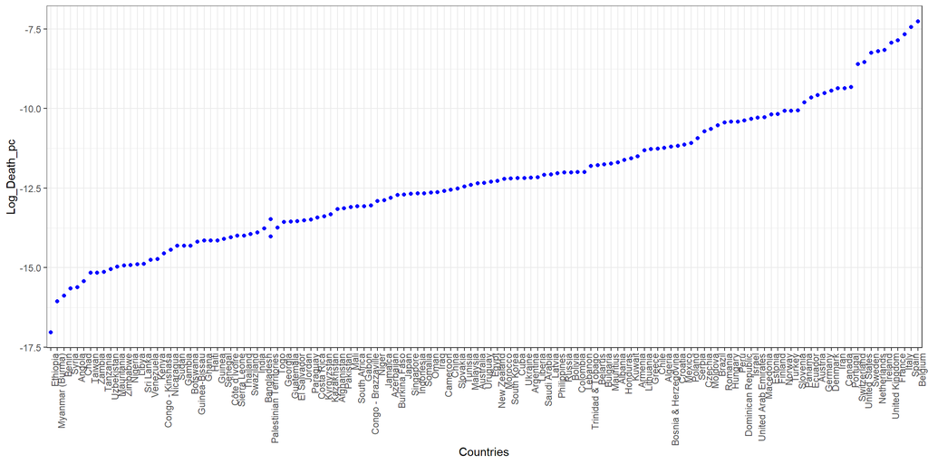

Figure 3.1: Death by country

What does restriction of movement do to total cases of death? Hard to answer this question.

Figure 3.2 plots the relation between Total Deaths per capita and Movement. The relation is endogenous. In principle, one would expect that lower movelemt -> less deaths. But of course, it may be that the countries that took the lock-down more seriously are the ones that were afflicted the most (higher death toll). I estimate the variable before_Google, that counts how many deaths were officially confirmed before Google’s observation period began. I estimate this variable as:

$$log(\frac{(Deaths(before23/02/2020)+1)}{Population})$$

I add +1 in the numerator, because there are many countries with 0 reported deaths before google, and logging leads to -Inf. Not sure if this is the right approach, maybe I should let them drop out.

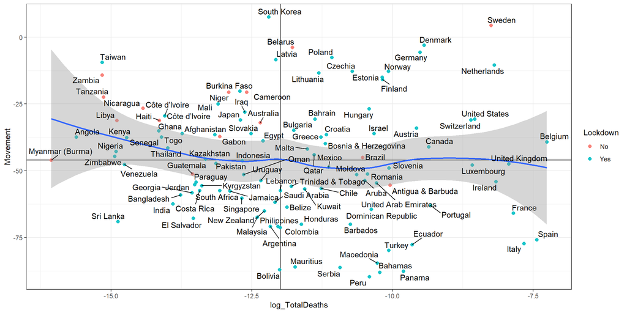

Figure 3.2: Movement restriction and Death

It’s interesting to look at those 4 quadrants. First, notice that quadrants 1 and 3 (low deaths) are typically comprised of countries that are less likely to be accurately reporting deaths (limited interest and/or medical supplies). Perhaps we can control for that with a proxy for health-services (e.g. hospital beds per capita).

Is there a story about the second quadrant? Nordic countries seem to dominate this quadrant of high-movement & high death rate. Is this is a story of climate or can we fit an explanation with a political science twist (e.g. Individualistic vs. Collective countries)? See relevant section.

Moreover, how do we control for the direction of causality? Edit: the more recent Mobility reports no longer produce a negative relation between movement and death. Probably because it takes some time for the quarantine to have an effect on deaths. It’s unlikely that reducing movement increases total deaths. More likely, the countries that were stricter at reducing mobility were the ones that were mostly affected by Covid. I create the before_Google variable that tracks down the number of deaths attributed to covid-19 before the observation period started. We would expect that this control will reduce the effect of mobility on total deaths.

|  | Log_Death_pc |  |  |
| --- | --- | --- | --- |
| Predictors | Estimates | CI | p |
| (Intercept) | -12.38 | -13.22 – -11.53 | **<0.001** |
| Movement | -0.01 | -0.03 – 0.01 | 0.196 |
| Observations | 117 |  |  |
| R<sup>2</sup> / R<sup>2</sup> adjusted | 0.014 / 0.006 |  |  |

|  | Log_Death_pc |  |  |
| --- | --- | --- | --- |
| Predictors | Estimates | CI | p |
| (Intercept) | -1.29 | -4.08 – 1.51 | 0.363 |
| Movement | -0.01 | -0.02 – 0.00 | 0.140 |
| before_Google | 0.71 | 0.53 – 0.89 | **<0.001** |
| Observations | 102 |  |  |
| R<sup>2</sup> / R<sup>2</sup> adjusted | 0.387 / 0.375 |  |  |

The coefficient of Movement is reduced but not nearly as much as I would have thought… Maybe the amount of deaths before Google’s observation period is not a good predictor.

## 3.1 Dynamic movement restriction and death

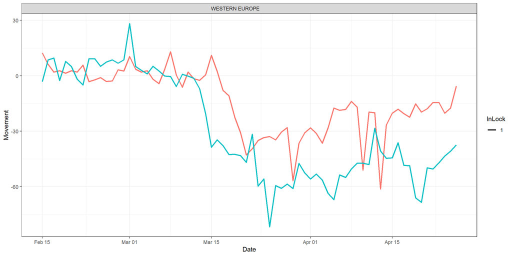

Figure 3.3: Reaction to LockDown

[output not shown]

# 4 Flattening the curve

Just started playing around with dynamic trends.

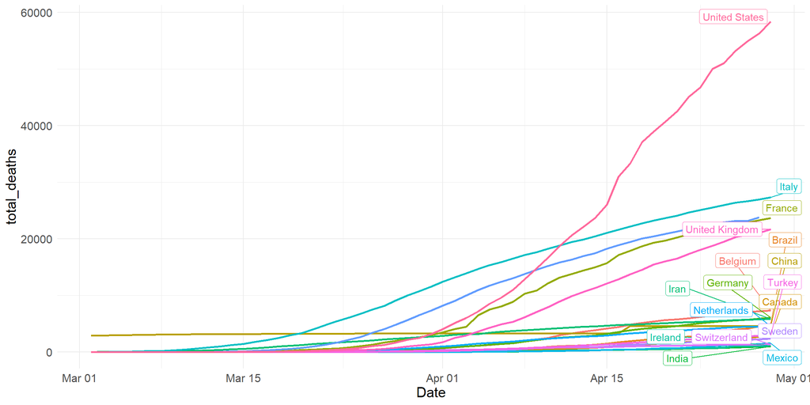

Figure 4.1: Death curve

# 5 Change in Movement by Regime Type

The figure below plots changes in movement as reported by google around the time of the lockdown (Note: Change in movement is still relative to google’s baseline).

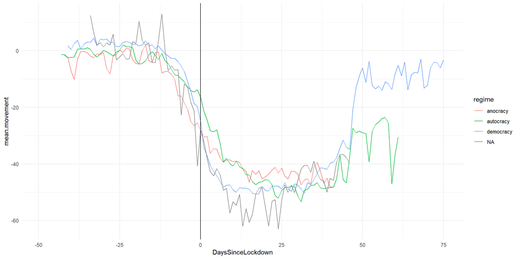

Across regime types (PolityIV), movement was noticeably reduced before the imposition of formal lockdowns. This might be because of informal appeals, citizens’ own initiative or fear, or weaker policy measures that didn’t qualify as a fully-fledged lockdown.

While all curves seem to move together quite neatly (no difference across regimes), there is a niticeable fivergence after something like 45 days, where movement in democracies picks up much more than autocracies. I do however suspect that this is based on a very small sample at that point, as not many countries have been in a lockdown for that long.

NB: We might want to start coding lifting/relaxation of lockdowns.

# 6 Collectivism

From the LSE article:

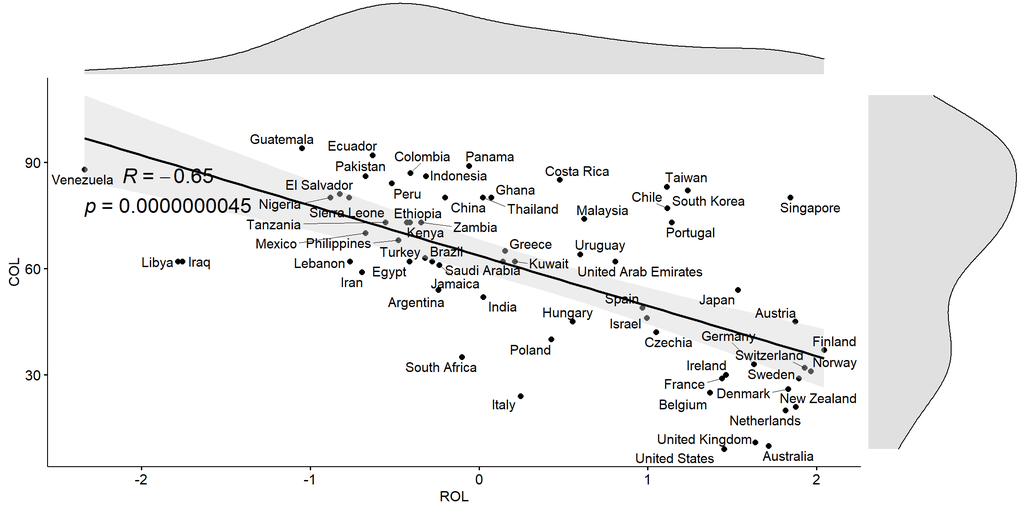

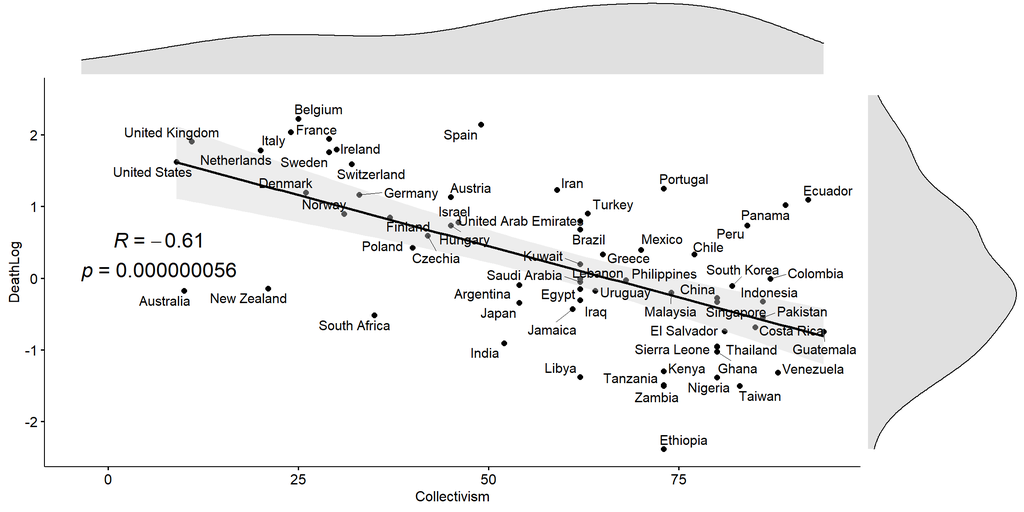

Figure 6.2: Collectivism by Total Death

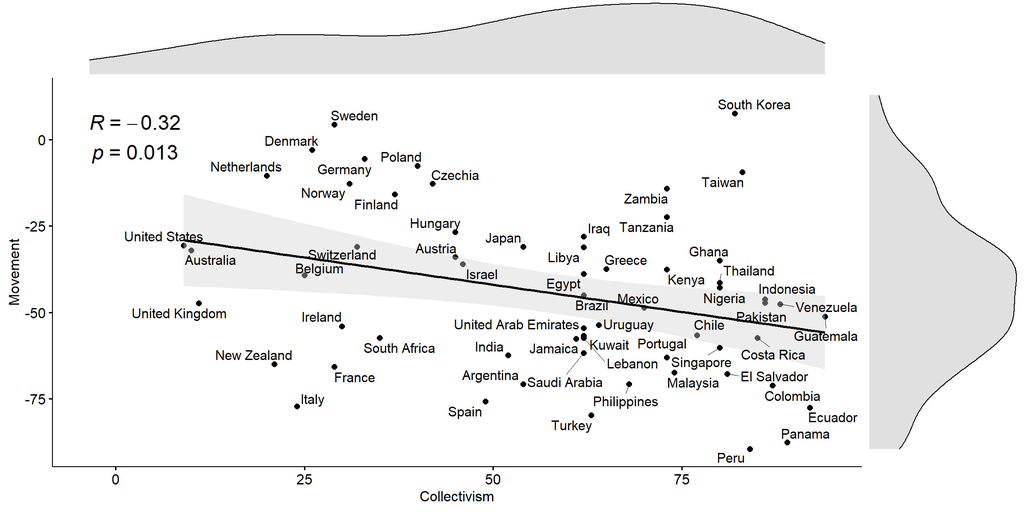

Figure 6.3: Collectivism by Movement

So… collectivism seems to be really powerfull… Though not as powerful as in the LSE paper (I think R=-065 in their case). But the LSE article uses CaseLog “Trajectory”. Not sure how they calculate this. It is also adjusted for population.

Let’s do the Movement - Death figure again but this time for those countries that we have a score for collectivism.

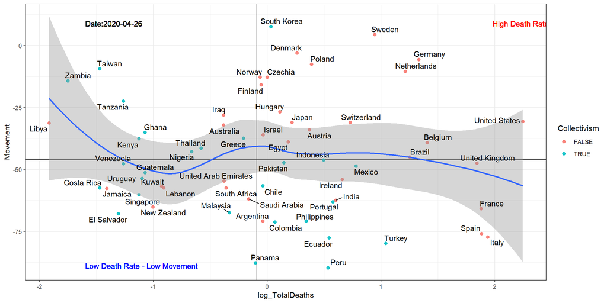

Figure 6.4: Movement restriction and Death - Collectivism

# 7 Patience

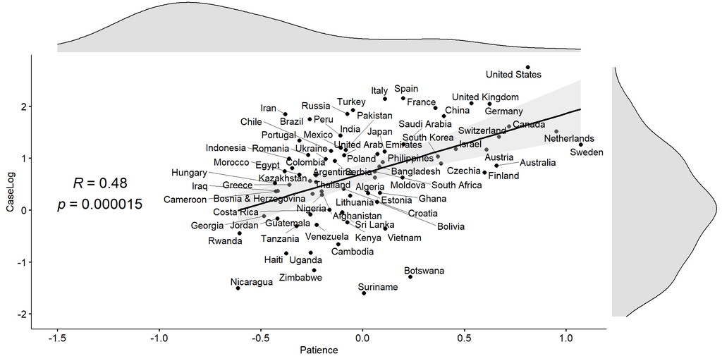

Figure 7.1: Patience by Total Cases

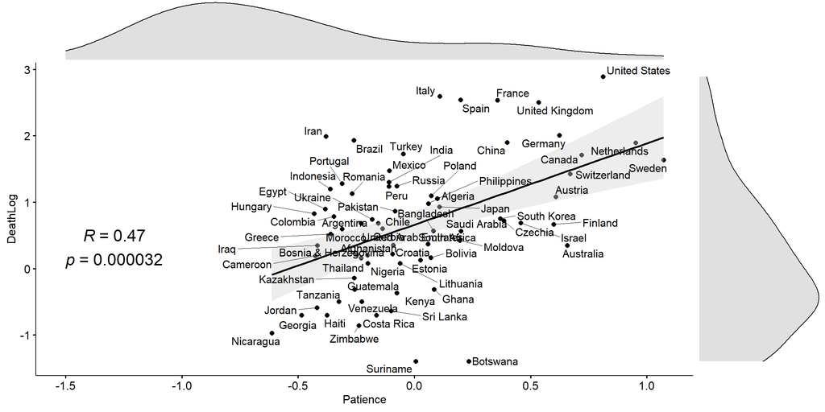

Figure 7.2: Patience by Total Death

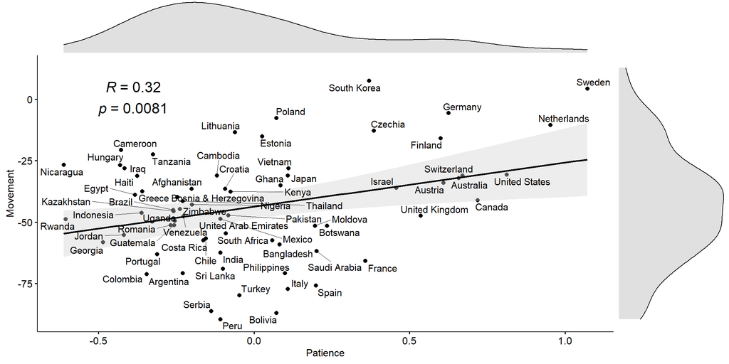

Figure 7.3: Patience by Movement

And patience is not bad either…

# 8 Risk Taking

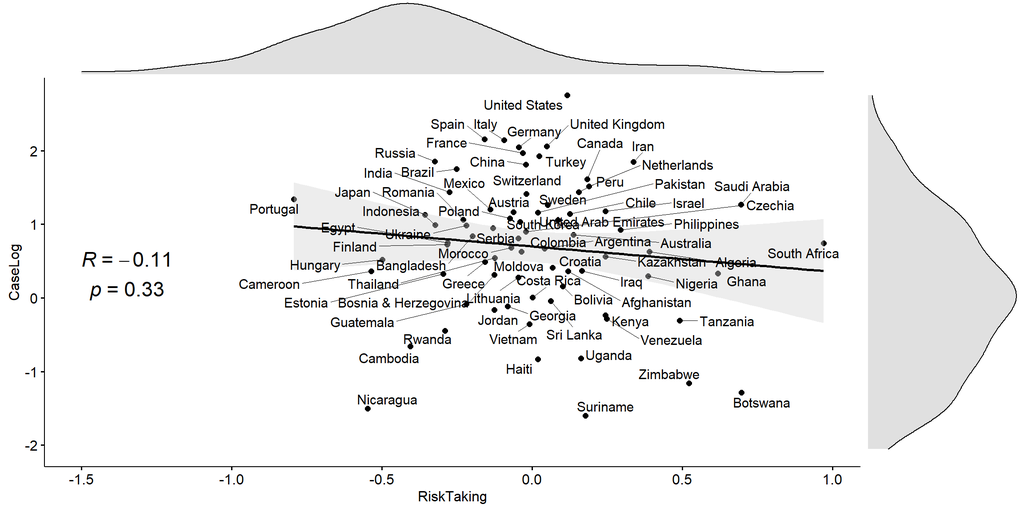

Figure 8.1: Risk Taking by Total Cases

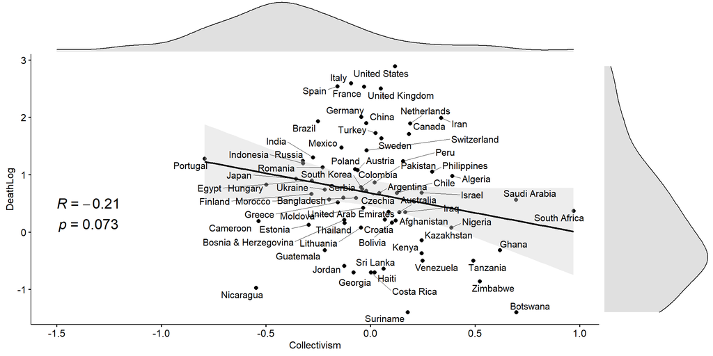

[figure not shown]

Figure 8.3: Risk Taking by Movement

Risk taking… not so great.

# 9 Rule of Law

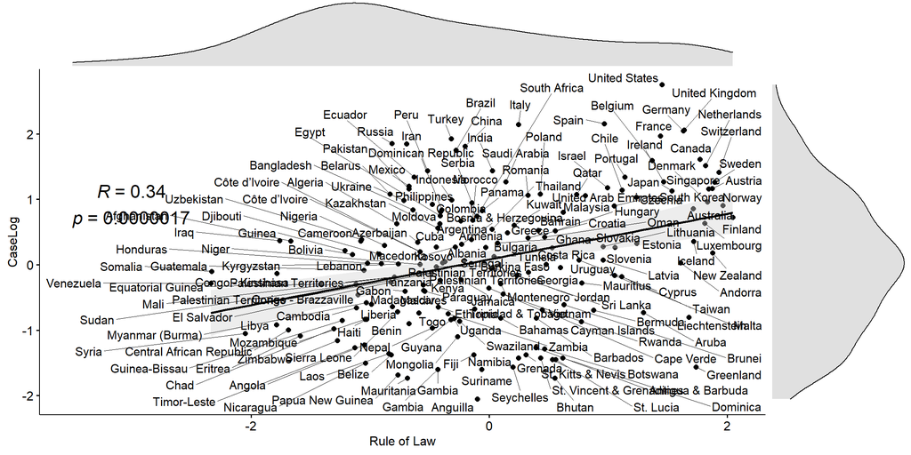

Figure 9.1: Rule of Law by Total Cases

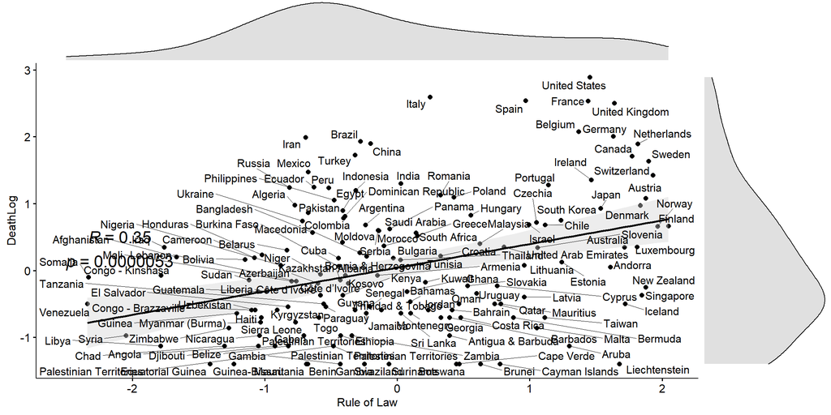

Figure 9.2: Rule of Law by Total Death

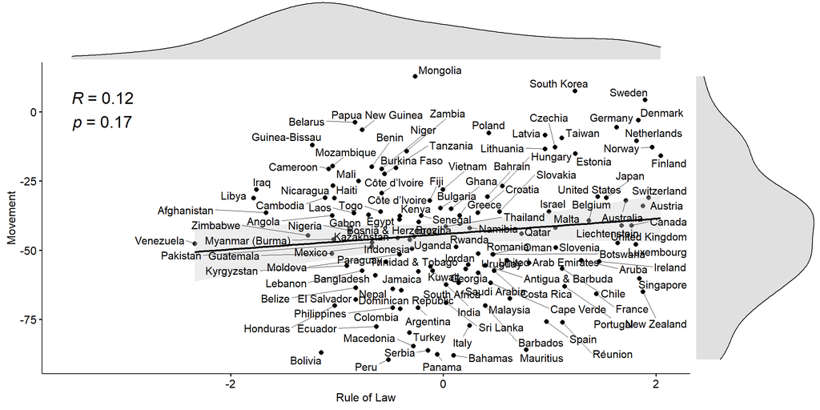

Figure 9.3: Rule of Law by Movement

Rule of Law… meh…